# Check Ghost Detectors

Adam Lyon

2017-03-07

# Executive Summary

## Conclusions:

- Hits on the ghost cylinder seem resonable
- I see many double hits that Renee does not in her file. But she is using a slightly larger cylinder that covers the injection region. I am seeing muons entering the ring, and hitting my cylinder that does not cover that region, thus making a spurious hit.
- Examined an event with four Ghost cylinder hits. For this event, the muon entered the yoke iron and extensively scattered, thus re-entering and re-exiting the cylinder.

## Technical notes

- For `rgl`,
- Do not use `rgl.clear`. Use `clear3d()` insted.
- If you get a grey background, issue `open3d()` to return to normalcy
- Use `view3d` to set the initial view. Still haven’t figured out how to read the current view from wegbl

# Introduction

Renee created a Ghost cylinder detector that surrounds the vacuum chamber outer wall to find particles that are lost. The goal here is to have confidence that these hits make sense, especially if a particle makes more than one hit in the ghost detector. I have also added a ghost “near world” detector that is a cylinder just inside the world cube. Those hits should also make sense. I have turned on detailed stepping data to look at if we find a strange event.

# Obtain the data

Use PyRoot to access the data.

```r
# Load useful libraries
library(reticulate)
library(stringr)
library(dplyr)
library(ggplot2)
```

Set up the python side

```r
py_config()
```

```
## python:         /cvmfs/gm2.opensciencegrid.org/prod7/external/python/v2_7_11/Linux64bit+3.10-2.17/bin/python
## libpython:      /cvmfs/gm2.opensciencegrid.org/prod7/external/python/v2_7_11/Linux64bit+3.10-2.17/lib/libpython2.7.so
## pythonhome:     /cvmfs/gm2.opensciencegrid.org/prod7/external/python/v2_7_11/Linux64bit+3.10-2.17:/cvmfs/gm2.opensciencegrid.org/prod7/external/python/v2_7_11/Linux64bit+3.10-2.17
## version:        2.7.11 (default, May  2 2016, 15:20:38)  [GCC 4.8.5 20150623 (Red Hat 4.8.5-4)]
## numpy:          /home/me/.local/lib/python2.7/site-packages/numpy
## numpy_version:  1.12.0
##
## python versions found:
##  /cvmfs/gm2.opensciencegrid.org/prod7/external/python/v2_7_11/Linux64bit+3.10-2.17/bin/python
##  /usr/bin/python
```

```r
# main is our connection to the python session
main <- py_run_string('
import ROOT
import numpy
import random
import time
')
```

We have `numpy`, but we won’t use it.

Prepare PyRoot to read gallery data

```r
# Helper function to read a header into PyROOT
read_header <- function(h) {
  str_interp("ROOT.gROOT.ProcessLine('#include \"${h}\"')", list(h=h)) %>%
    py_run_string()
}

# Load in gallery information
read_header("gallery/ValidHandle.h")

# Load in dictionary and prepare to get a handle
provide_get_valid_handle <- function(klass) {
  paste0("ROOT.gROOT.ProcessLine(",
         "'template gallery::ValidHandle<",klass,"> ",
         "gallery::Event::getValidHandle<",klass,">(art::InputTag const&) const;')") %>%
    py_run_string()
}
```

We want to look at `GhostDetectorArtRecord` (see http://tinyurl.com/gkrd6aj). Note that the input tag for the ring ghost is `artg4:GhostCylinderDetector` and for the “near world” ghost it is `artg4:GhostNearWorldDetector`.

```r
# Prepare for GhostDetectorArtRecord
provide_get_valid_handle('std::vector<gm2truth::GhostDetectorArtRecord>')
```

Prepare the input tags

```r
py_run_string("
cylIT = ROOT.art.InputTag('artg4:GhostCylinderDetector')
nwIT  = ROOT.art.InputTag('artg4:GhostNearWorldDetector')
")
```

Make the file list for our only file

```r
artFile = "/home/me/gm2/renee_arr/try/ARR_unified_noInflector_cyl.root"
main$artFile = artFile
py_run_string("
files = ROOT.vector(ROOT.string)(1, artFile)
")
```

Define a helper function to fill the data

```r
py_run_string('
def fill(ev, w, g, cols, rnge):
  row = [w, ev.eventEntry(), ev.fileEntry(), g.particleID, g.trackID, g.parentTrackID,
            g.position.x(), g.position.y(), g.position.z(),
            g.momentum.x(), g.momentum.y(), g.momentum.z()]
  [ cols[i].append(row[i]) for i in rnge ]   # side-effect here!
')
```

Load the Ghost detector data

```r
py_run_string('

ev = ROOT.gallery.Event(files)  # Open the file

get_gh = ev.getValidHandle(ROOT.vector(ROOT.gm2truth.GhostDetectorArtRecord)) # Prepare the getter

# Prepare the columns
colNames = ["which", "eventEntry", "fileEntry", "particleID", "trackID", "parentTrackID",
            "x", "y", "z", "px", "py", "pz"]  # This ordering is important
forRange = xrange(len(colNames))
allVals = [ [] for i in forRange ]

# Keep track of timing
startTotalTime = time.clock()
times = []

# Loop over events with gallery
while not ev.atEnd():
  startTime = time.clock()

  # Get handles to the data
  gd_cyl_h = get_gh(cylIT)

  # Fill the cylinder Ghost hit data
  if not gd_cyl_h.empty():
    gd_cyl = gd_cyl_h.product()
    for g in gd_cyl:
      fill(ev, 0, g, allVals, forRange)

  # Do the same for the near world hits
  gd_nw_h  = get_gh(nwIT)
  if not gd_nw_h.empty():
    gd_nw = gd_nw_h.product()
    for g in gd_nw:
      fill(ev, 1, g, allVals, forRange)

  times.append(time.clock() - startTime)
  ev.next()
print "Total Processing time is %s s" % (time.clock() - startTotalTime)
print "Created %s rows" % (len(allVals[0]))
')

l <- main$allVals ; names(l) <- main$colNames ; df <- tbl_df(l)
```

We need to clean up the data a little:

- Turn `particleID` into a name (see http://pdg.lbl.gov/2007/reviews/montecarlorpp.pdf)
- Turn `which` into a name

```r
# The PDG values we need to care about
df %>% distinct(particleID) %>% arrange(particleID) -> pdgVals
pdgVals
```

```
## # A tibble: 7 × 1
##   particleID
##        <int>
## 1        -14
## 2        -13
## 3        -11
## 4         11
## 5         12
## 6         22
## 7       2112
```

```r
# The corresponding PDG names
pdgNames <- c("anti-nu-mu", "mu+", "e+", "e-", "nu-e", "gam", "n")
```

```r
# Do the conversions and drop the old columns
df %>% mutate(pdg = factor(particleID, levels=pdgVals$particleID, labels=pdgNames),
                w = factor(which, levels=c(0,1), labels=c("cyl", "nw"))) -> df
df
```

```
## # A tibble: 2,092 × 14
##    which eventEntry fileEntry particleID trackID parentTrackID        x
##    <int>      <int>     <int>      <int>   <int>         <int>    <dbl>
## 1      0          0         0        -13       1             0 6702.466
## 2      0          0         0        -13       1             0 5890.218
## 3      0          0         0         22     278            18 6881.422
## 4      0          0         0         12     155             1 5476.861
## 5      0          0         0         12     155             1 6721.956
## 6      0          0         0         22     667           370 5138.552
## 7      0          0         0         22     667           370 4366.752
## 8      0          0         0         22     664           370 5310.678
## 9      0          0         0         22     664           370 5214.092
## 10     0          0         0         22     650           528 5065.217
## # ... with 2,082 more rows, and 7 more variables: y <dbl>, z <dbl>,
## #   px <dbl>, py <dbl>, pz <dbl>, pdg <fctr>, w <fctr>
```

# Analyze primary muon hits in cylinder ghost detector

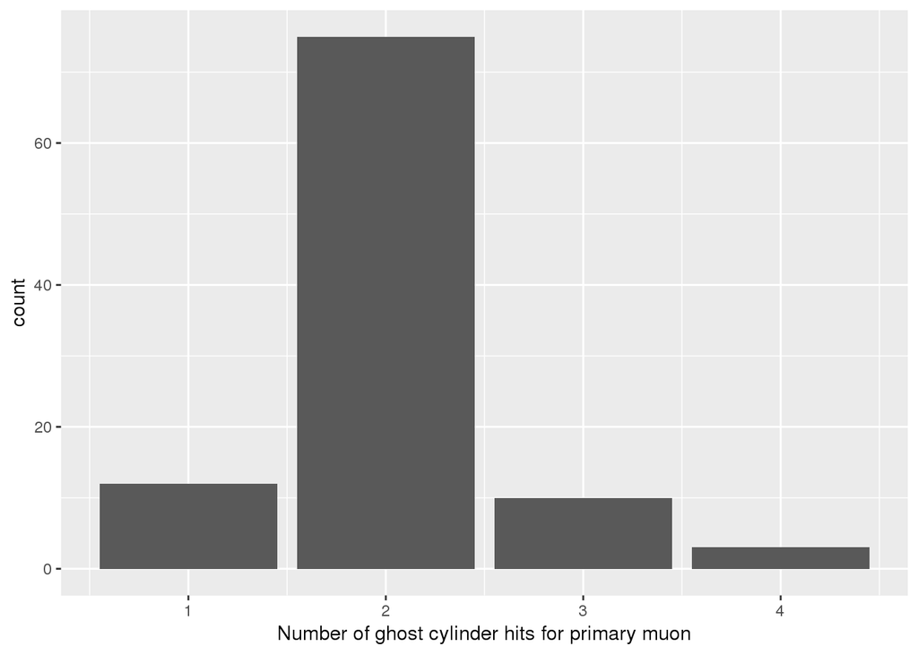

```r
df %>% filter(w == 'cyl', pdg == 'mu+', trackID == 1, parentTrackID == 0) -> mus
mus %>% group_by(eventEntry) %>% summarise(n = n()) -> cylHitsPerEvent
ggplot(cylHitsPerEvent, aes(n)) + geom_bar() + xlab('Number of ghost cylinder hits for primary muon')
```

How many mupn ghost cylinder hits to we see total?

```r
cylHitsPerEvent %>% summarise(total = sum(n))
```

```
## # A tibble: 1 × 1
##   total
##   <int>
## 1   204
```

**NOTE: Renee says that my code has the wrong radius for the Ghost cylinder!! She made a correction that makes it a little bigger. I’ll try this code. She thinks that will make many of these double hits go away.**

Where are these hits?

```r
# Load a 3D graphics library
library(rgl)
tmp <- open3d()  # see http://tinyurl.com/hcxy9nh
```

Make a cylindrical representation of the ring

```r
ring <- cylinder3d( center=rbind(c(0,-90, 0), c(0,90,0)),
                    radius=7112,
                    sides=20, closed = F)
```

```r
clear3d()
plot3d(x=mus$x, y=mus$y, z=mus$z, type='p', main='Ghost Cylinder Hits',
       xlab="x", ylab="y", zlab="z", xlim=c(-9000, 9000), zlim=c(-9000, 9000))
plot3d(ring, add=T, alpha=0.2)
rglwidget()
```

[interactive chart not shown]

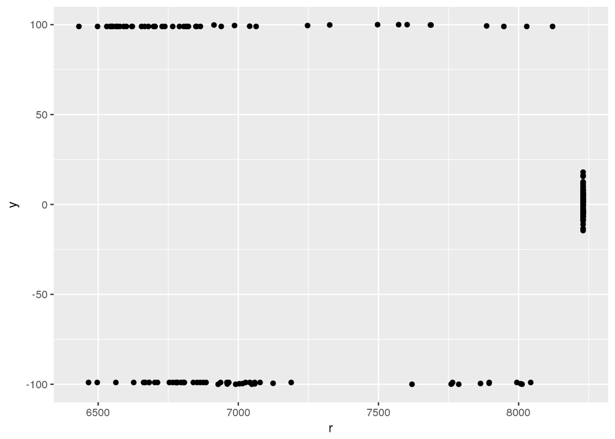

```r
mus %>% mutate(r = sqrt(x*x+z*z)) -> mus
ggplot(mus, aes(r,y)) +  geom_point()
```

And if we unroll the ring…

```r
mus %>% mutate(phirad = atan2(z,x))  %>% mutate(phideg = ifelse(phirad>=0, phirad, 2*pi+phirad)*180/pi) -> mus
```

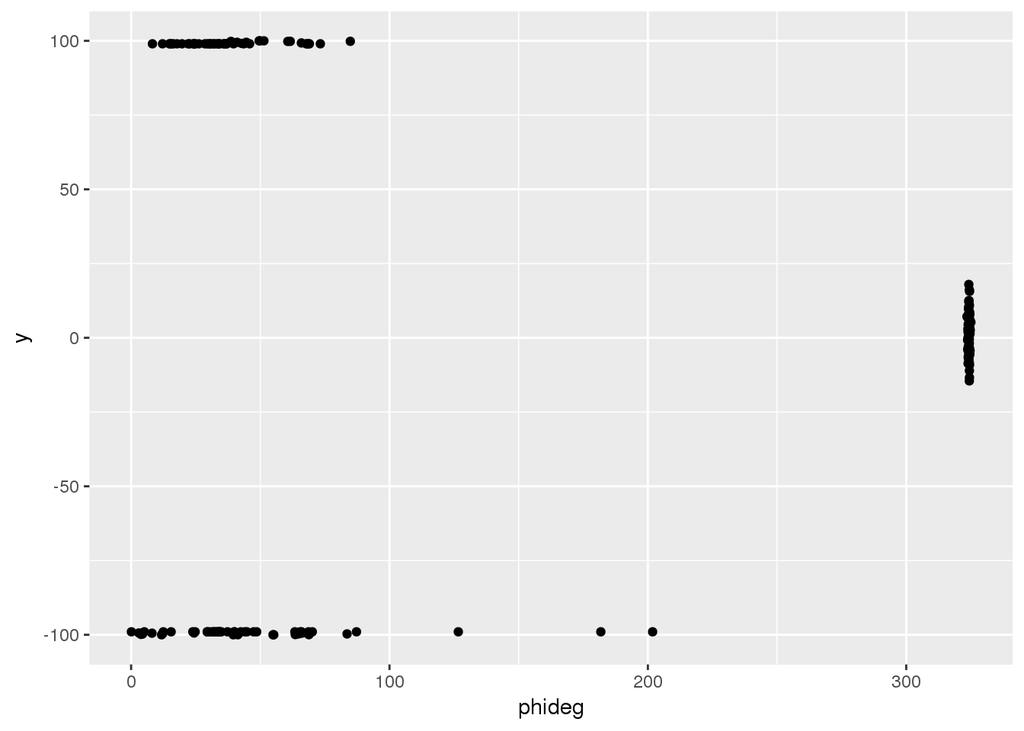

```r
ggplot(mus, aes(phideg, y)) + geom_point()
```

## Mulitple cylindrical ghost hits

Let’s look at some events with more than one hit in the ghost detector for the muon.

```r
cylHitsPerEvent %>% filter(n==4)
```

```
## # A tibble: 3 × 2
##   eventEntry     n
##        <int> <int>
## 1         55     4
## 2         56     4
## 3         83     4
```

### Focus on event 55

```r
names(mus)
```

```
##  [1] "which"         "eventEntry"    "fileEntry"     "particleID"
##  [5] "trackID"       "parentTrackID" "x"             "y"
##  [9] "z"             "px"            "py"            "pz"
## [13] "pdg"           "w"             "r"             "phirad"
## [17] "phideg"
```

```r
mus %>% filter(eventEntry == 55) %>%
        mutate(r = sqrt(x*x+z*z),
               p = sqrt(px*px+py*py+pz*pz)) %>%
        select(r, x, y, z, p)
```

```
## # A tibble: 4 × 5
##          r        x         y         z        p
##      <dbl>    <dbl>     <dbl>     <dbl>    <dbl>
## 1 8230.000 6708.693 -5.606864 -4767.215 3089.400
## 2 7685.361 3656.287 99.824228  6759.906 1612.852
## 3 7885.857 3220.045 99.291227  7198.476  845.965
## 4 8028.993 2877.735 99.000000  7495.557  340.549
```

There are some hints here!

Where are those hits?

```r
clear3d()
with(mus %>% filter(eventEntry==55), {
  plot3d(x=x, y=y, z=z, type='p', main='Ghost Cylinder Hits',
         xlab="x", ylab="y", zlab="z", xlim=c(-9000, 9000), zlim=c(-9000, 9000))
  plot3d(ring, add=T, alpha=0.2)
})
view3d(phi=90, theta=-90)
rglwidget()
```

[interactive chart not shown]

Let’s get the stepping data

```r
provide_get_valid_handle('std::vector<gm2ringsim::GeantTrackRecord>')
```

```r
py_run_string("gtIT = ROOT.art.InputTag('artg4:KeepStepsAction')")
```

We’re going to return both the `GeantTrackRecord` and the constituent `GeantStep` objects. Let’s organize things

```r
py_run_string('

class GeantTrackDF:
  def __init__(self):
    self.colNames = ["eventEntry", "fileEntry", "trackID", "parentID", "pdgValue", "status", "nSteps"]
    self.forRange = xrange(len(self.colNames))
    self.vals = [ [] for i in self.forRange ]

  def fill(self, ev, g):
    row = [ev.eventEntry(), ev.fileEntry(), g.trackID(), g.parentId(), g.pdg(), g.trackStatus(), g.steps().size() ]
    [ self.vals[i].append(row[i]) for i in self.forRange ]   # side-effect here!

class GeantStepDF:
  def __init__(self):
    self.colNames = ["eventEntry", "fileEntry", "trackID", "globalStepNum", "e", "dt", "l", "gt", "lt",
                     "x", "y", "z", "px", "py", "pz"]
    self.forRange = xrange(len(self.colNames))
    self.vals = [ [] for i in self.forRange ]

  def fill(self, trackID, ev, s):
    row = [ev.eventEntry(), ev.fileEntry(), trackID, s.globalStepNum(), s.totalEnergyDeposit(),
           s.deltaTime(), s.stepLength(), s.localTime(), s.globalTime(), s.pos()[0], s.pos()[1], s.pos()[2],
           s.p()[0], s.p()[1], s.p()[2] ]
    [ self.vals[i].append(row[i]) for i in self.forRange ]   # side-effect here!
')
```

```r
py_run_string('

ev = ROOT.gallery.Event(files)  # Open the file

get_gt = ev.getValidHandle(ROOT.vector(ROOT.gm2ringsim.GeantTrackRecord)) # Prepare the getter

# Prepare the columns
gtdf = GeantTrackDF()
gsdf = GeantStepDF()

# Keep track of timing
startTotalTime = time.clock()
times = []

# Loop over events with gallery
while not ev.atEnd():

  if ev.eventEntry() != 55: # Only event 55
    ev.next()
    continue

  startTime = time.clock()

  # Get handles to the data
  gt_h = get_gt(gtIT)

  # Fill the GeantTrackRecord
  if not gt_h.empty():
    gt = gt_h.product()
    for aTrack in gt:
      gtdf.fill(ev, aTrack)

      # Get the steps
      gs = aTrack.steps()
      for aStep in gs:
        gsdf.fill(aTrack.trackID(), ev, aStep)

  times.append(time.clock() - startTime)
  ev.next()

print "Total Processing time is %s s" % (time.clock() - startTotalTime)
')

gtl <- main$gtdf$vals ; names(gtl) <- main$gtdf$colNames ; gtdf <- tbl_df(gtl)
gsl <- main$gsdf$vals ; names(gsl) <- main$gsdf$colNames ; gsdf <- tbl_df(gsl)
```

```r
nrow(gtdf)
```

```
## [1] 771
```

```r
nrow(gsdf)
```

```
## [1] 3519
```

Just get the muon steps

```r
gsdf %>% filter(trackID==1) %>% arrange(globalStepNum)-> muSteps
muSteps
```

```
## # A tibble: 234 × 15
##    eventEntry fileEntry trackID globalStepNum            e          dt
##         <int>     <int>   <int>         <dbl>        <dbl>       <dbl>
## 1          55         0       1             1 2.125369e-23 0.869849477
## 2          55         0       1             2 2.125369e-23 0.869849477
## 3          55         0       1             3 1.705290e-25 0.006979237
## 4          55         0       1             4 2.446497e-23 1.001277349
## 5          55         0       1             5 2.446497e-23 1.001277349
## 6          55         0       1             6 2.446497e-23 1.001277349
## 7          55         0       1             7 2.446497e-23 1.001277349
## 8          55         0       1             8 2.446497e-23 1.001277349
## 9          55         0       1             9 2.446497e-23 1.001277349
## 10         55         0       1            10 2.446497e-23 1.001277349
## # ... with 224 more rows, and 9 more variables: l <dbl>, gt <dbl>,
## #   lt <dbl>, x <dbl>, y <dbl>, z <dbl>, px <dbl>, py <dbl>, pz <dbl>
```

Let’s try to plot them!

```r
clear3d()
with(mus %>% filter(eventEntry==55), {
  plot3d(x=x, y=y, z=z, type='s', main='Ghost Cylinder Hits',
         xlab="x", ylab="y", zlab="z", xlim=c(-9000, 9000), zlim=c(-9000, 9000))
  plot3d(ring, add=T, alpha=0.2)
})

with(muSteps,{
  plot3d(x=x, y=y, z=z, col="red", add=T, type='p')
})
view3d(theta=45, phi=45)
rglwidget()
```

[interactive chart not shown]

Another view - our normal top down view

```r
view3d(phi=90, theta=-90)
rglwidget()
```

[interactive chart not shown]

```r
par3d()$scale
```

```
## [1]   0.8165044 132.3643494   0.8165044
```

```r
par3d()$scale
```

```
## [1]   0.8165044 132.3643494   0.8165044
```

That’s quite a trip that the muon took!

Look at a table we did above…

```r
mus %>% filter(eventEntry == 55) %>%
        mutate(r = sqrt(x*x+z*z),
               p = sqrt(px*px+py*py+pz*pz)) %>%
        select(r, x, y, z, p)
```

```
## # A tibble: 4 × 5
##          r        x         y         z        p
##      <dbl>    <dbl>     <dbl>     <dbl>    <dbl>
## 1 8230.000 6708.693 -5.606864 -4767.215 3089.400
## 2 7685.361 3656.287 99.824228  6759.906 1612.852
## 3 7885.857 3220.045 99.291227  7198.476  845.965
## 4 8028.993 2877.735 99.000000  7495.557  340.549
```

This is from the ghost cylinder hits. The momentum drops dramatically for each of the ‘u-turns’. Looks like scattering!

Let’s look at energy loss vs step number…

```r
names(muSteps)
```

```
##  [1] "eventEntry"    "fileEntry"     "trackID"       "globalStepNum"
##  [5] "e"             "dt"            "l"             "gt"
##  [9] "lt"            "x"             "y"             "z"
## [13] "px"            "py"            "pz"
```

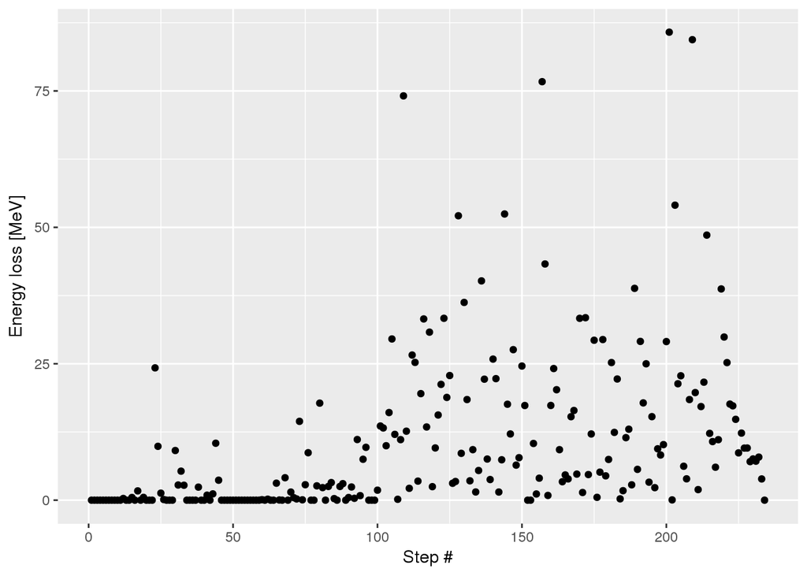

```r
muSteps %>% ggplot(aes(globalStepNum, e)) + geom_point() + xlab('Step #') + ylab('Energy loss [MeV]')
```

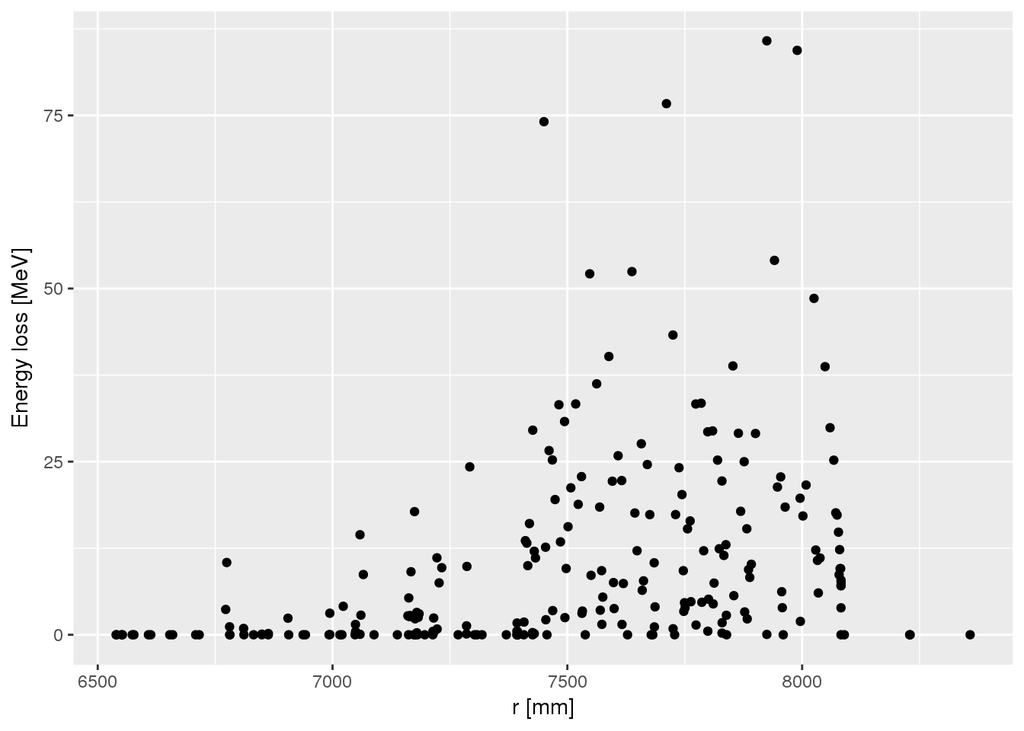

```r
muSteps %>% mutate(r = sqrt(x*x+z*z)) %>%
  ggplot(aes(r, e)) + geom_point() + xlab('r [mm]') + ylab('Energy loss [MeV]')
```

Would be fun to see this ParaView.